# Understanding Patient Experience and how we can improve that at blah hospital

## In the next few steps, we will extract key terms and create a corpus of the tweet text. We will use the corpus to see refined word clouds that may give us more in depth look into what users are sharing about patient experience on Twitter.

```python
#read in the dataframe we saved above
patientexpDf = pd.read_csv("TwitterPatient-LocationEdited.csv")
print(patientexpDf.shape)
print(list(patientexpDf)) #feature space
```

```
(483, 13)
['Unnamed: 0', 'tweetID', 'userID', 'tweetText', 'userScreenName', 'userName', 'userDesc', 'tweetRetweetCt', 'tweetFavoriteCt', 'userFollowerCt', 'userFriendsCt', 'userLocation', 'tweetCreated']
```

```python
patientexpDf.tweetText = patientexpDf.tweetText.fillna(' ')
```

A lot of the words are hashtags from the companies sharing on twitter, technology use in healthcare etc and not patient's own experience. So below we will try to mute some of the buzz words and get close to sentiment

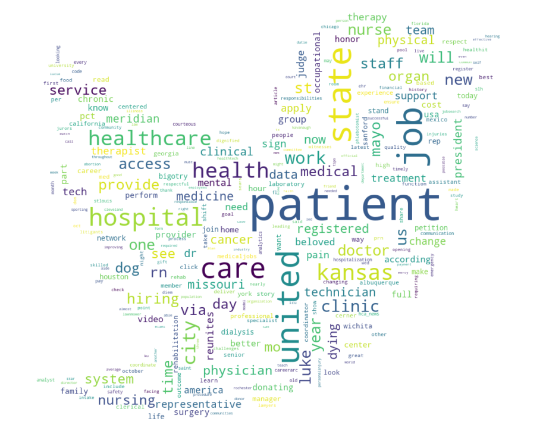

```python
show_words_cloud(patientexpDf.tweetText.str.cat(sep=' '), None, 300)
```

```python
from sklearn.feature_extraction.text import CountVectorizer


boldStart = "\033[1m"
boldEnd = "\033[0;0m"

def featureCounts(vectorizer, cv_dm=None, *features):
    for feature in features:
        if cv_dm is None:
            cv_dm = vectorizer.fit_transform(feature)
        print(boldStart + "\nFeature space: " + feature.name + boldEnd ,cv_dm.shape)
        names = vectorizer.get_feature_names()   #create list of feature names
        count = np.sum(cv_dm.toarray(), axis = 0) # add up feature counts
        count2 = count.tolist()  # convert numpy array to list
        count_df = pd.DataFrame(count2, index = names, columns = ['count']) # create a dataframe from the list
    return count_df.sort_values(['count'], ascending = False)[0:10]  #arrange by count instead of alphabetical (top 20)
```

```python
basicCV = CountVectorizer(ngram_range=(1,4), min_df=2, max_df=1.0, binary = False)
basicCV_dm = basicCV.fit_transform(patientexpDf.tweetText)
basicCVArr = basicCV_dm.toarray()

basicCVText = featureCounts(basicCV, basicCV_dm, patientexpDf['tweetText'])
basicCVText
```

```
Feature space: tweetText (483, 5303)
```

|  | count |
| --- | --- |
| the | 485 |
| patient | 472 |
| and | 307 |
| to | 288 |
| of | 256 |
| in | 203 |
| states | 198 |
| united | 196 |
| united states | 193 |
| care | 148 |

```python
from sklearn.feature_extraction.text import CountVectorizer, TfidfVectorizer
from nltk.corpus import stopwords
# instantiate vectorizer
```

```python
basicTfdf = TfidfVectorizer(lowercase=True,
                        max_df=0.95,
                        min_df=0.05,
                        ngram_range = (1,2),  use_idf = True)
basicTfdf_dm = basicTfdf.fit_transform(patientexpDf.tweetText)
basicTfdfArr = basicTfdf_dm.toarray()

basicTfDfText = featureCounts(basicTfdf, basicTfdf_dm, patientexpDf['tweetText'])
basicTfDfText
```

```
Feature space: tweetText (483, 71)
```

|  | count |
| --- | --- |
| the | 72.518488 |
| patient | 57.963488 |
| and | 52.283176 |
| to | 50.585670 |
| of | 43.756455 |
| states | 40.318749 |
| united | 40.260774 |
| united states | 39.720503 |
| in | 39.154170 |
| care | 31.823186 |

```python
basicTfdfNoInv = TfidfVectorizer(lowercase=True,
                        max_df=0.95,
                        min_df=0.05,
                        ngram_range = (1,2))
basicTfdfNoInv_dm = basicTfdfNoInv.fit_transform(patientexpDf.tweetText)
basicTfdfNoInvArr = basicTfdfNoInv_dm.toarray()

basicTfDfNoInvText = featureCounts(basicTfdfNoInv, basicTfdfNoInv_dm, patientexpDf['tweetText'])
basicTfDfNoInvText
```

```
Feature space: tweetText (483, 71)
```

|  | count |
| --- | --- |
| the | 72.518488 |
| patient | 57.963488 |
| and | 52.283176 |
| to | 50.585670 |
| of | 43.756455 |
| states | 40.318749 |
| united | 40.260774 |
| united states | 39.720503 |
| in | 39.154170 |
| care | 31.823186 |

```python
#create an object storing the default nltk stopwords
from nltk.corpus import stopwords

nltk_stopwords = stopwords.words("english")
stopwords = nltk_stopwords + ["patient", "hospital", "https", "healthcare", "united", "states", "united states"]
```

```python
# NLTK also has tokenizers
import nltk
from nltk import word_tokenize

def tokenize(row):
    text = cleanText(row.lower())
    wordList = str(text.lower()).split() #splits the text apart before stemming
    token2Text = ''
    wordPos = pos_tag(wordList)
    for item in wordPos:
        if item[0] not in stopwords:
            token2Text = token2Text + ' ' + item[0]
        token2Text = token2Text.replace('jobs', 'job')
    if trimToNone(token2Text) == 'None':
        print(text)
    #print(token2Text)
    return token2Text


def pos_tag(word):
    token2Text = nltk.pos_tag(word)
    return token2Text
```

```python
patientexpDf['tokenText'] = patientexpDf.tweetText.apply(lambda x: tokenize(x))

patientexpDf.tokenText = patientexpDf.tokenText.fillna(' ')
```

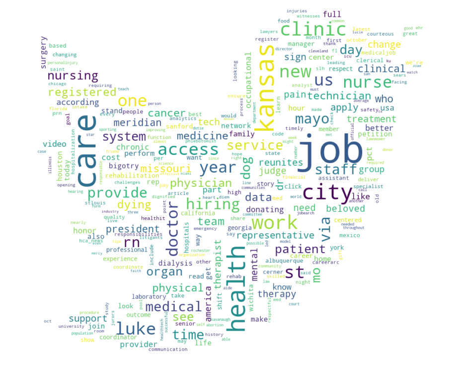

```python
show_words_cloud(patientexpDf.tokenText.str.cat(sep=' '), stopwords=stopwords, count=300)
```

```python
procCV = CountVectorizer(ngram_range=(1,4), stop_words=stopwords, min_df=2, max_df=1.0, binary = False)
procCV_dm = procCV.fit_transform(patientexpDf.tweetText)
procCVArr = procCV_dm.toarray()

procCVTokenText = featureCounts(procCV, procCV_dm, patientexpDf.tokenText)
procCVTokenText
```

```
Feature space: tokenText (483, 3423)
```

|  | count |
| --- | --- |
| care | 148 |
| job | 130 |
| jobs | 99 |
| kansas | 87 |
| health | 82 |
| city | 61 |
| kansas city | 57 |
| work | 48 |
| clinic | 44 |
| st | 42 |

```python
procTfDf = TfidfVectorizer(lowercase=True, stop_words=stopwords,
                        max_df=0.95,
                        min_df=0.05,
                        ngram_range = (1,2),  use_idf = True)
procTfDf_dm = procTfDf.fit_transform(patientexpDf.tweetText)
procTfDfArr = procTfDf_dm.toarray()

procTfDfText = featureCounts(procTfDf, procTfDf_dm, patientexpDf['tweetText'])
procTfDfText
```

```
Feature space: tweetText (483, 27)
```

|  | count |
| --- | --- |
| care | 56.471012 |
| job | 45.938577 |
| kansas | 40.654337 |
| jobs | 38.846981 |
| health | 34.665175 |
| city | 27.005921 |
| via | 26.017567 |
| us | 25.308636 |
| kansas city | 24.716220 |
| new | 24.631194 |

```python
procTfDfNoInv = TfidfVectorizer(lowercase=True, stop_words=stopwords,
                        max_df=0.95,
                        min_df=0.05,
                        ngram_range = (1,2))
procTfDfNoInv_dm = procTfDfNoInv.fit_transform(patientexpDf.tweetText)
procTfDfNoInvArr = procTfDfNoInv_dm.toarray()

procTfDfNoInvText = featureCounts(procTfDfNoInv, procTfDfNoInv_dm, patientexpDf['tweetText'])
procTfDfNoInvText
```

```
Feature space: tweetText (483, 27)
```

|  | count |
| --- | --- |
| care | 56.471012 |
| job | 45.938577 |
| kansas | 40.654337 |
| jobs | 38.846981 |
| health | 34.665175 |
| city | 27.005921 |
| via | 26.017567 |
| us | 25.308636 |
| kansas city | 24.716220 |
| new | 24.631194 |

Repeat same for tfidf

#### Topic Analysis

```python
#new GI dictionary
import re
GI_frame = pd.read_csv('inquirerbasic.csv', low_memory=False,
                       #usecols=[0,1,2,3,6,7,8,10,15,16,18,19,20,21,22,29,32,64,65,66,68,70,112,113,114,177,178,184,185],
                      na_values = [" "])


GI_frame.fillna('', inplace=True)
# get rid of multiple counts
GI_frame['NewEntry'] = GI_frame['Entry'].str.extract('([A-Z]\w{0,})', expand = False)
```

```python
import nltk

def pos_tag(row):
    tokenText = word_tokenize(cleanText(row))
    token2Text = nltk.pos_tag(tokenText)
    #print(token2Text)
    #if empty array
    if not token2Text:
        return ''

    return token2Text

patientexpDf['pos'] = patientexpDf["tokenText"].apply(lambda x: pos_tag(x))
```

```python
techPromoWords = ["tech","digitalhealth", "healthcareit", 'data',
             "technology", "AI", "webinar",
             "artificialintelligence", "internetofthings", "IoT",
             "healthtech", "himss", "hcr", "hcit", "healthit", "video", "competition", "achieve", "achieved",
            "capital", "resources", "ahead", "ping", "pinged", "access", "improvedaccess", "record", "records",
             "code", "codes", "revolutionary", "state-of-the-art", "excellence", "reputation", "learn", "watch",
             "credit card", "credit", "dataprivacy", "information", "report", "reports",
             "telehealth", "tele", "telemedicine", "recommend", "hiring", "job", "latest", "metrics", "monitoring",
             "healthsystems", "nurses", "meds"]

#add our search terms also in promo/tech as it helps to bucket tweets mentioning these terms
techPromoWords.extend(terms)

wlbWords = ["coverage", "blood", "donate", "organ", "surgeries", "clinical", "appointments", "appointment",
           "pharmacist", "support", "loss", "perios", "life", "lifesaving", "saving", "transplant", "grateful",
           "theraupatic", "organs", "donor", "cancer", "honor", "staff", "gift", "donation", "respect", "bless",
           "family", "tribute", "donating", "donate", 'ptsd', "beloved", "dog"]

improvWords = ["feedback", "lovely", "stealing", "lie", "ugly", "shouting", "beautiful", "see", "beloved"]
```

```python
#http://www.wjh.harvard.edu/~inquirer/homecat.htm
GIlist = GI_frame['NewEntry'].tolist()
GIlist = list(map(lambda x: str(x).lower(), GIlist))
GIset = set(GIlist)

##First extract the sentiment columns of interest from GI dictionary
#positive sentiment
GIpos = GI_frame['NewEntry'][GI_frame['Positiv'].str.contains('Positiv')].tolist()
GIyes = GI_frame['NewEntry'][GI_frame['Yes'].str.contains('Yes')].tolist()
GIposAff = GI_frame['NewEntry'][GI_frame['PosAff'].str.contains('PosAff')].tolist()
GIfeel = GI_frame['NewEntry'][GI_frame['Feel'].str.contains('Feel')].tolist()
GIemot = GI_frame['NewEntry'][GI_frame['EMOT'].str.contains('EMOT')].tolist()

#negative sentiment
GIneg = GI_frame['NewEntry'][GI_frame['Negativ'].str.contains('Negativ')].tolist()
GIno = GI_frame['NewEntry'][GI_frame['No'].str.contains('No')].tolist()
GInegAff = GI_frame['NewEntry'][GI_frame['NegAff'].str.contains('NegAff')].tolist()
GIpain = GI_frame['NewEntry'][GI_frame['Pain'].str.contains('Pain')].tolist()
GIfail = GI_frame['NewEntry'][GI_frame['Fail'].str.contains('Fail')].tolist()
GIhostile = GI_frame['NewEntry'][GI_frame['Hostile'].str.contains('Hostile')].tolist()

#negate
GInegate = GI_frame['NewEntry'][GI_frame['Negate'].str.contains('Negate')].tolist()

#techAndLegal and promo words
GIPolit = GI_frame['NewEntry'][GI_frame['POLIT'].str.contains('POLIT')].tolist()
GIpolit = GI_frame['NewEntry'][GI_frame['Polit@'].str.contains('Polit@')].tolist()
GIlegal = GI_frame['NewEntry'][GI_frame['Legal'].str.contains('Legal')].tolist()
#promoWords need to identify and add a list of words

#well being sentiment
wlbGain = GI_frame['NewEntry'][GI_frame['WlbGain'].str.contains('WlbGain')].tolist()
wlbLoss = GI_frame['NewEntry'][GI_frame['WlbLoss'].str.contains('WlbLoss')].tolist()
wlbPhys = GI_frame['NewEntry'][GI_frame['WlbPhys'].str.contains('WlbPhys')].tolist()
wlbPsyc = GI_frame['NewEntry'][GI_frame['WlbPsyc'].str.contains('WlbPsyc')].tolist()
wlbPt = GI_frame['NewEntry'][GI_frame['WlbPt'].str.contains('WlbPt')].tolist()
wlbTot = GI_frame['NewEntry'][GI_frame['WlbTot'].str.contains('WlbTot')].tolist()

#Areas of improvement: actively working to improve or need to improve
GIneed = GI_frame['NewEntry'][GI_frame['Need'].str.contains('Need')].tolist()
GIgoal = GI_frame['NewEntry'][GI_frame['Goal'].str.contains('Goal')].tolist()
GItry = GI_frame['NewEntry'][GI_frame['Try'].str.contains('Try')].tolist()

#Scale
GIstrong = GI_frame['NewEntry'][GI_frame['Strong'].str.contains('Strong')].tolist()
GIweak = GI_frame['NewEntry'][GI_frame['Weak'].str.contains('Weak')].tolist()

##Now group sentiment columns to buckets/scale: Postive, Negative, techLegalPromo (?), Well being, Areas of Improvement

#Positive
GIpos = list(map(lambda x: str(x).lower(), GIpos))
GIpos.extend(list(map(lambda x: str(x).lower(), GIyes)))
GIpos.extend(list(map(lambda x: str(x).lower(), GIposAff)))
#GIpos.extend(list(map(lambda x: str(x).lower(), GIfeel)))
#GIpos.extend(list(map(lambda x: str(x).lower(), GIemot)))

#Negative
GIneg = list(map(lambda x: str(x).lower(), GIneg))
GIneg.extend(list(map(lambda x: str(x).lower(), GIno)))
GIneg.extend(list(map(lambda x: str(x).lower(), GInegAff)))
GIneg.extend(list(map(lambda x: str(x).lower(), GIpain)))
GIneg.extend(list(map(lambda x: str(x).lower(), GIfail)))
GIneg.append('stealing')
GIneg.append('abuse')
GIneg.append('lying')
GIneg.append('shouting')

#Well being
GIWlb = list(map(lambda x: str(x).lower(), wlbGain))
GIWlb.extend(list(map(lambda x: str(x).lower(), wlbLoss)))
GIWlb.extend(list(map(lambda x: str(x).lower(), wlbPhys)))
GIWlb.extend(list(map(lambda x: str(x).lower(), wlbPsyc)))
GIWlb.extend(list(map(lambda x: str(x).lower(), wlbPt)))
GIWlb.extend(list(map(lambda x: str(x).lower(), wlbTot)))
GIWlb.extend(list(map(lambda x: str(x).lower(), wlbWords)))

#Tech, Political, Legal, Promo - words yet to be added
GIstatement = list(map(lambda x: str(x).lower(), GIPolit))
GIstatement.extend(list(map(lambda x: str(x).lower(), GIpolit)))
GIstatement.extend(list(map(lambda x: str(x).lower(), GIlegal)))
GIstatement.extend(list(map(lambda x: str(x).lower(), techPromoWords)))

#Areas of Improvement
GIArea = list(map(lambda x: str(x).lower(), GIneed))
GIArea.extend(list(map(lambda x: str(x).lower(), GIgoal)))
GIArea.extend(list(map(lambda x: str(x).lower(), GItry)))
GIArea.extend(list(map(lambda x: str(x).lower(), improvWords)))

#scale
GIstrong = list(map(lambda x: str(x).lower(), GIstrong))
GIweak = list(map(lambda x: str(x).lower(), GIweak))
```

```python
#Simple topic engine with PoS tagging
def topic(inputstring):
    #print(inputstring)
    #bucket counts and sign
    techLeglCount = 0
    wlbCount = 0
    imprvCount = 0

    i=0
    for word in inputstring:
        prev = inputstring[i-1]
        #print(word)
        ##Now increase count of every bucket the current word belongs to
        if word[0] in GIWlb:
            wlbCount+=1
            #print(word[0] + "wb")
        if word[0] in GIstatement:
            techLeglCount+=1
            #print(word[0] + "tech")
        if word[0] in GIArea:
            imprvCount+=1
            #print(word[0] + "improv")
        i+=1

    #print("Tech =", techLeglCount)
    #print("Well being =", wlbCount)
    #print("Area improve =", imprvCount)

    label = ''
    if techLeglCount > 2:
        label = label +  'Tech '
    if wlbCount > 2:
        label = label +  'WellBeing '
    if imprvCount > 2:
        label = label +  'AreaOfImprovement '

    if label == '':
        label = max3(techLeglCount, 'Tech ', wlbCount, 'WellBeing ', imprvCount, 'AreaOfImprovement ')
    #print(sentiment,"\n****************\n")
    return label

def max3(x, xlab,y, ylab, z, zlab):
    Max = x
    Maxlbl = xlab
    if y > Max:
        Max = y
        Maxlbl = ylab
    if z > Max:
        Max =z
        Maxlbl = zlab
    #print(Max)
    return Maxlbl

#Simple topic engine with PoS tagging
def sentiment(inputstring, penalize=False):
    #print(inputstring)
    #bucket counts and sign

    sentimentCount = 0
    i=0
    for pos in inputstring:
        word = pos[0]
        #print("word=", word)
        ##Now increase count of every bucket the current word belongs to
        if word in GIpos or word in GIstrong:
            sentimentCount+=1
        elif word in GIneg or word in GIweak:
            sentimentCount-=1
        i+=1

    #print("Tech =", techLeglCount)
    #print("Well being =", wlbCount)
    #print("Area improve =", imprvCount)

    label = 'Neutral'
    if sentimentCount > 0:
        label = 'Positive'
    elif sentimentCount < 0:
        label = 'Negative'

    #print(sentiment,"\n****************\n")
    return label
```

#### Create topic labels for tweet text

For brevity, we are calling the label 'Tech' but this label indicates Tech, promo, innovation or hospital and patient care specific news and industry following. This category helps to analyze the on going changes, keep us updated of job openings, what efforts other hospitals are making to hire, technology updates that may help improve our patient care and much more

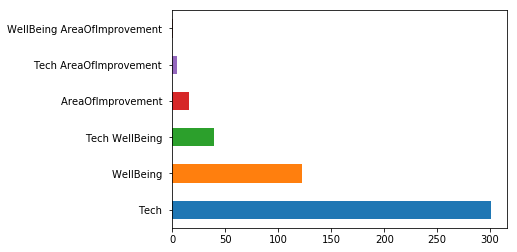

```python
patientexpDf['topic'] = patientexpDf['pos'].apply(lambda x: topic(x))

#drop rows with no labels as not relevant to our analysis
patientexpDf = patientexpDf.drop(patientexpDf[patientexpDf.topic == ''].index)

patientexpDf['topic'].value_counts().plot(kind='barh')
```

```python
patientexpDf[patientexpDf.topic == 'Tech '].iloc[[4,13,15]]
```

|  | Unnamed: 0 | tweetID | userID | tweetText | userScreenName | userName | userDesc | tweetRetweetCt | tweetFavoriteCt | userFollowerCt | userFriendsCt | userLocation | tweetCreated | tokenText | pos | topic |
| --- | --- | --- | --- | --- | --- | --- | --- | --- | --- | --- | --- | --- | --- | --- | --- | --- |
| 6 | 369 | 1048714904583041024 | 784162579790692352 | patient care coordinator - (albuquerque new mexico united states) | unmhjobs | unmh jobs | unmh is a nationally recognized leader in quality care now hiring for nursing positions in nm | 0 | 0 | 121 | 3 | albuquerque nm | 2018-10-06 23:21:32 | care coordinator - (albuquerque new mexico states) | [(care, NN), (coordinator, NN), (-, :), ((, (), (albuquerque, JJ), (new, JJ), (mexico, NN), (states, NNS), (), ))] | Tech |
| 16 | 479 | 1046847249895084033 | 65779710 | aca senior scientific advisor christine goertz dc phd has been appointed by the comptroller of the united states to a three-year term as vice chair of the patient-centered outcomes research institute … | acatoday | american chiro assn | aca is changing chiropractic by setting higher standards collaborating with other health care professionals and focusing on evidence-based methods | 2 | 8 | 13492 | 636 | arlington va | 2018-10-01 19:40:08 | aca senior scientific advisor christine goertz dc phd appointed comptroller three-year term vice chair patient-centered outcomes research institute (pcori) board governors | [(aca, RB), (senior, JJ), (scientific, JJ), (advisor, NN), (christine, NN), (goertz, NN), (dc, NN), (phd, NN), (appointed, VBN), (comptroller, NN), (three-year, JJ), (term, NN), (vice, NN), (chair, NN… | Tech |
| 19 | 434 | 1047534104957341696 | 344263789 | there are almost 6400 lawnmower injuries a year in the united states most requiring surgery and hospitalization that cost an average of nearly $37000 a patient according to a new study personalinjury | kainelaw | evan kaine | NaN | 0 | 0 | 118 | 11 | atlanta ga | 2018-10-03 17:09:27 | almost 6400 lawnmower injuries year requiring surgery hospitalization cost average nearly $37000 according new study personalinjury | [(almost, RB), (6400, CD), (lawnmower, JJR), (injuries, NNS), (year, NN), (requiring, VBG), (surgery, NN), (hospitalization, NN), (cost, NN), (average, JJ), (nearly, RB), ($, $), (37000, CD), (accordi… | Tech |

```python
patientexpDf[patientexpDf.topic == 'WellBeing '].iloc[[1,3]]
```

|  | Unnamed: 0 | tweetID | userID | tweetText | userScreenName | userName | userDesc | tweetRetweetCt | tweetFavoriteCt | userFollowerCt | userFriendsCt | userLocation | tweetCreated | tokenText | pos | topic |
| --- | --- | --- | --- | --- | --- | --- | --- | --- | --- | --- | --- | --- | --- | --- | --- | --- |
| 3 | 158 | 1048037343012241408 | 588718308 | dying kansas woman gets to see her beloved dog one more time via @whnt | daleonard9 | debl | i put the lord first and foremost in my life also love to read (mostly nonfiction) and love animals ultra ultra conservative both fiscally & socially | 0 | 0 | 390 | 688 | alabama | 2018-10-05 02:29:08 | dying kansas woman gets see beloved dog one time via @whnt | [(dying, VBG), (kansas, NNS), (woman, NN), (gets, VBZ), (see, VBP), (beloved, VBN), (dog, VB), (one, CD), (time, NN), (via, IN), (@, NNP), (whnt, NN)] | WellBeing |
| 20 | 100 | 1047271896377696256 | 2164124363 | at st luke's meridian hospital they have a beautiful tradition they call the walk of respect” \n\nbefore a patient donates their organs all available staff members meet on the 4th floor to pay their r… | brennasimonsays | brenna simon | studying public health and economics warning: this twitter account may contain careless spelling and grammatical errors instagram: brennasimonsays | 22 | 82 | 5973 | 392 | atlanta georgia | 2018-10-02 23:47:32 | st luke's meridian beautiful tradition call walk respect” donates organs available staff members meet 4th floor pay respects show support patient’s family | [(st, NN), (luke, NN), ('s, POS), (meridian, JJ), (beautiful, JJ), (tradition, NN), (call, NN), (walk, VBP), (respect, NN), (”, NN), (donates, NNS), (organs, NNS), (available, JJ), (staff, NN), (membe… | WellBeing |

#### Create Sentiment labels for tweet text

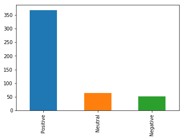

```python
patientexpDf['sentiment'] = patientexpDf['pos'].apply(lambda x: sentiment(x))
patientexpDf['sentiment'].value_counts().plot(kind='bar')
```

### Analyze interesting clusters here, tweak as needed for e.g: add or remove stop words, change GI sentiment categories or algorithm, reduce no. of cluster labels, etc.

### Interesting results from this will be added to presentation

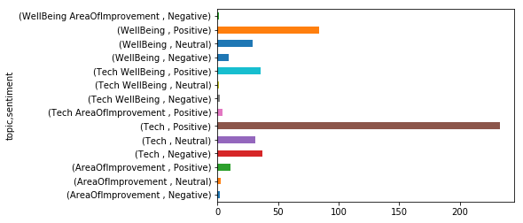

```python
patientexpDf.groupby(['topic','sentiment'])['tokenText'].count().plot(kind="barh")
```

```python
a = patientexpDf
b = pd.DataFrame(a.topic.str.split().tolist(), index=a.sentiment).stack()
b = b.reset_index()[[0, 'sentiment']] # var1 variable is currently labeled 0
b.columns = ['topic', 'sentiment'] # renaming var1
```

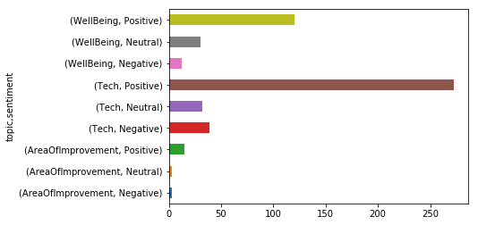

```python
b.groupby(['topic','sentiment'])['topic'].count().plot(kind="barh")
```

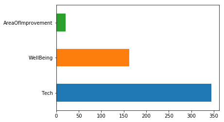

```python
b['topic'].value_counts().plot(kind='barh')
```

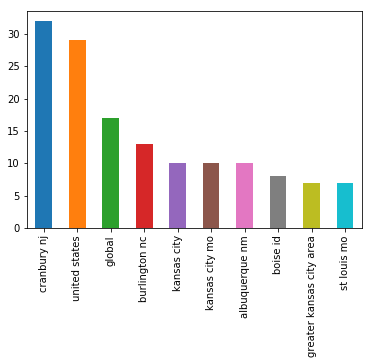

```python
patientexpDf.userLocation.value_counts().nlargest(10).plot(kind='bar')
```

```python
patientexpDf = patientexpDf[['tweetID', 'userID', 'userScreenName', 'userName', 'userDesc', 'tweetRetweetCt', 'tweetFavoriteCt', 'userFollowerCt', 'userFriendsCt', 'userLocation', 'tweetCreated', 'tweetText', 'tokenText', 'pos', 'topic', 'sentiment']]
```

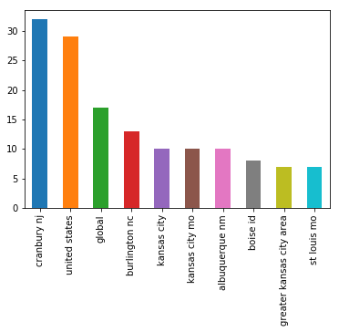

```python
patientexpDf.userLocation.value_counts().nlargest(10).plot(kind='bar')
```

```python
techPositive = patientexpDf[(patientexpDf['topic'].str.contains('Tech')) & (patientexpDf['sentiment'] == 'Positive')]

techPositive.iloc[[19,14]]
```

|  | tweetID | userID | userScreenName | userName | userDesc | tweetRetweetCt | tweetFavoriteCt | userFollowerCt | userFriendsCt | userLocation | tweetCreated | tweetText | tokenText | pos | topic | sentiment |
| --- | --- | --- | --- | --- | --- | --- | --- | --- | --- | --- | --- | --- | --- | --- | --- | --- |
| 69 | 1047811086081187840 | 3167974176 | chicago_hire | chicago jobs | ✨ new jobs daily ✨ be first to apply for the very latest jobs tweeting jobs from ★ ★ the 1 most searched job site job jobs hiring | 0 | 0 | 83 | 85 | chicago il | 2018-10-04 11:30:04 | senior clinical systems analyst: senior clinical systems analyst 600 w fulton chicago illinois 60606 united states about access community health network designated as a level 3 patient-centered medica… | senior clinical systems analyst: senior clinical systems analyst 600 w fulton chicago illinois 60606 access community health network designated level 3 patient-centered medical home national committee… | [(senior, JJ), (clinical, JJ), (systems, NNS), (analyst, NN), (:, :), (senior, JJ), (clinical, JJ), (systems, NNS), (analyst, NN), (600, CD), (w, JJ), (fulton, NN), (chicago, NN), (illinois, NN), (606… | Tech WellBeing | Positive |
| 58 | 1047161972523978752 | 50159254 | patient_safety | cpsi - icsp | the canadian patient safety institute tweets ptsafety and cdnhealth information we were created by @govcanhealth in 2003 | 1 | 1 | 10579 | 758 | canada | 2018-10-02 16:30:44 | teamstepps canada™ developed by the united states department of defense and the ahrq improves safety and transforms culture in healthcare through better teamwork and communication next session is oct … | teamstepps canada™ developed department defense ahrq improves safety transforms culture better teamwork communication next session oct 23-24 deadline reg oct 5th! cdnhealth | [(teamstepps, NN), (canada™, NN), (developed, VBD), (department, NN), (defense, NN), (ahrq, NN), (improves, VBZ), (safety, NN), (transforms, NNS), (culture, NN), (better, RBR), (teamwork, NN), (commun… | Tech | Positive |

```python
techNegative = patientexpDf[(patientexpDf['topic'].str.contains('Tech')) & (patientexpDf['sentiment'] == 'Negative')]
len(techNegative)
```

```
39
```

```python
techNegative.iloc[[1,2]]
```

|  | tweetID | userID | userScreenName | userName | userDesc | tweetRetweetCt | tweetFavoriteCt | userFollowerCt | userFriendsCt | userLocation | tweetCreated | tweetText | tokenText | pos | topic | sentiment |
| --- | --- | --- | --- | --- | --- | --- | --- | --- | --- | --- | --- | --- | --- | --- | --- | --- |
| 18 | 1047534115115941888 | 533205751 | lawsend | lawsmith attorneys | NaN | 0 | 0 | 103 | 476 | atlanta ga | 2018-10-03 17:09:29 | there are almost 6400 lawnmower injuries a year in the united states most requiring surgery and hospitalization that cost an average of nearly $37000 a patient according to a new study personalinjury | almost 6400 lawnmower injuries year requiring surgery hospitalization cost average nearly $37000 according new study personalinjury | [(almost, RB), (6400, CD), (lawnmower, JJR), (injuries, NNS), (year, NN), (requiring, VBG), (surgery, NN), (hospitalization, NN), (cost, NN), (average, JJ), (nearly, RB), ($, $), (37000, CD), (accordi… | Tech | Negative |
| 19 | 1047534104957341696 | 344263789 | kainelaw | evan kaine | NaN | 0 | 0 | 118 | 11 | atlanta ga | 2018-10-03 17:09:27 | there are almost 6400 lawnmower injuries a year in the united states most requiring surgery and hospitalization that cost an average of nearly $37000 a patient according to a new study personalinjury | almost 6400 lawnmower injuries year requiring surgery hospitalization cost average nearly $37000 according new study personalinjury | [(almost, RB), (6400, CD), (lawnmower, JJR), (injuries, NNS), (year, NN), (requiring, VBG), (surgery, NN), (hospitalization, NN), (cost, NN), (average, JJ), (nearly, RB), ($, $), (37000, CD), (accordi… | Tech | Negative |

```python
wellBeingPositive = patientexpDf[(patientexpDf['topic'].str.contains('WellBeing')) & (patientexpDf['sentiment'] == 'Positive')]
wellBeingPositive.iloc[[2,100]]
```

|  | tweetID | userID | userScreenName | userName | userDesc | tweetRetweetCt | tweetFavoriteCt | userFollowerCt | userFriendsCt | userLocation | tweetCreated | tweetText | tokenText | pos | topic | sentiment |
| --- | --- | --- | --- | --- | --- | --- | --- | --- | --- | --- | --- | --- | --- | --- | --- | --- |
| 24 | 1046110525149646848 | 21654555 | griffglen | glen griffiths | positive outlook - facts are the basis of co-operation | 0 | 0 | 988 | 1543 | berkshire uk | 2018-09-29 18:52:39 | @jfdb15 hi - this may be of interest prof j bachman md mayo clinic (2010) subjective element of consultation supported through potential of computer/patient interviewing | @jfdb15 hi - may interest prof j bachman md mayo clinic (2010) subjective element consultation supported potential computer/patient interviewing | [(@, JJ), (jfdb15, NN), (hi, SYM), (-, :), (may, MD), (interest, NN), (prof, NN), (j, NN), (bachman, NN), (md, NN), (mayo, NN), (clinic, NN), ((, (), (2010, CD), (), )), (subjective, JJ), (element, NN… | WellBeing | Positive |
| 414 | 1049319507184033793 | 23157455 | wodelic | liz eff | so fucking tired | 0 | 0 | 1671 | 4995 | NaN | 2018-10-08 15:24:00 | @bigmanmattw @arieldumas okay i’m gonna explain this one to you bc i’m feeling patient: his life isn’t ruined- he is now a justice of the supreme court of the united states for life life in other word… | @bigmanmattw @arieldumas okay i’m gonna explain one bc i’m feeling patient: life isn’t ruined- justice supreme court life life words life made” ruined see works?? | [(@, JJ), (bigmanmattw, NN), (@, NNP), (arieldumas, IN), (okay, NN), (i, NN), (’, VBP), (m, NN), (gon, NN), (na, TO), (explain, VB), (one, CD), (bc, NN), (i, NN), (’, VBP), (m, NN), (feeling, NN), (pa… | Tech WellBeing | Positive |

```python
wellBeingNegative = patientexpDf[(patientexpDf['topic'].str.contains('WellBeing')) & (patientexpDf['sentiment'] == 'Negative')]
len(wellBeingPositive)
```

```
120
```

```python
wellBeingNegative.iloc[[8,9]]
```

|  | tweetID | userID | userScreenName | userName | userDesc | tweetRetweetCt | tweetFavoriteCt | userFollowerCt | userFriendsCt | userLocation | tweetCreated | tweetText | tokenText | pos | topic | sentiment |
| --- | --- | --- | --- | --- | --- | --- | --- | --- | --- | --- | --- | --- | --- | --- | --- | --- |
| 405 | 1046912650918203395 | 553067190 | mayoemployees | mayoclinic employees | this account is managed by public affairs to share information about mayo clinic following doesn’t=endorsement social media policy: | 0 | 0 | 1562 | 556 | NaN | 2018-10-02 00:00:01 | at mayo clinic i finally had doctors who listened to me and took my concerns seriously read about alley downing's cancer journey: | mayo clinic finally doctors listened took concerns seriously read alley downing's cancer journey: | [(mayo, NN), (clinic, NN), (finally, RB), (doctors, NNS), (listened, VBD), (took, VBD), (concerns, NNS), (seriously, RB), (read, VB), (alley, RP), (downing, VBG), ('s, POS), (cancer, NN), (journey, NN… | WellBeing | Negative |
| 408 | 1046073975917465600 | 909927376766746625 | carmasophia | carmen cutler | health advocate \| pots patient \| grad student in human rights \| researcher \| former and life-long teacher | 1 | 7 | 124 | 162 | NaN | 2018-09-29 16:27:25 | potsandbeyond2018 @dysautonomia @meactnet dr goodman mayo clinic az: we heard the patient panel yesterday describe how difficult it is to navigate the healthcare system we hear you | potsandbeyond2018 @dysautonomia @meactnet dr goodman mayo clinic az: heard panel yesterday describe difficult navigate system hear | [(potsandbeyond2018, NN), (@, NNP), (dysautonomia, NN), (@, NNP), (meactnet, NN), (dr, NN), (goodman, NN), (mayo, VBZ), (clinic, JJ), (az, NN), (:, :), (heard, NN), (panel, NN), (yesterday, NN), (desc… | WellBeing | Negative |

```python
areaImprovPositive = patientexpDf[(patientexpDf['topic'].str.contains('AreaOfImprovement')) & (patientexpDf['sentiment'] == 'Positive')]
areaImprovPositive.iloc[[7,9]]
```

|  | tweetID | userID | userScreenName | userName | userDesc | tweetRetweetCt | tweetFavoriteCt | userFollowerCt | userFriendsCt | userLocation | tweetCreated | tweetText | tokenText | pos | topic | sentiment |
| --- | --- | --- | --- | --- | --- | --- | --- | --- | --- | --- | --- | --- | --- | --- | --- | --- |
| 190 | 1046029372841480192 | 3350862225 | catreidtv | cat reid | reporter for @41actionnews former investigative mmj for @waaytv il native and alum of @medillschool equestrian and theater enthusiast rts not endorsements | 1 | 1 | 1255 | 1139 | kansas city mo | 2018-09-29 13:30:11 | honestly this is too much for my little heart to take nice work @kcchrism | honestly much little heart take nice work @kcchrism | [(honestly, RB), (much, JJ), (little, JJ), (heart, NN), (take, VB), (nice, JJ), (work, NN), (@, NN), (kcchrism, NN)] | AreaOfImprovement | Positive |
| 238 | 1047203382321184768 | 292963432 | lakelandpbs | lakeland pbs | our mission is to educate entertain enrich & enlighten our community with programming we create right here in mn as well as national content | 0 | 1 | 899 | 123 | north/central minnesota | 2018-10-02 19:15:17 | take a timely look at how one institution has met the changing demands of healthcare for 150 years—and what it can teach us about facing the challenges of patient care today — watch the mayo clinic: f… | take timely look one institution met changing demands 150 years—and teach us facing challenges care today — watch mayo clinic: faith - hope - science streaming devices online: | [(take, VB), (timely, JJ), (look, VB), (one, CD), (institution, NN), (met, VBD), (changing, VBG), (demands, NNS), (150, CD), (years—and, NN), (teach, VBP), (us, PRP), (facing, VBG), (challenges, NNS),… | Tech AreaOfImprovement | Positive |

```python
areaImprovNegative = patientexpDf[(patientexpDf['topic'].str.contains('AreaOfImprovement')) & (patientexpDf['sentiment'] == 'Negative')]
```

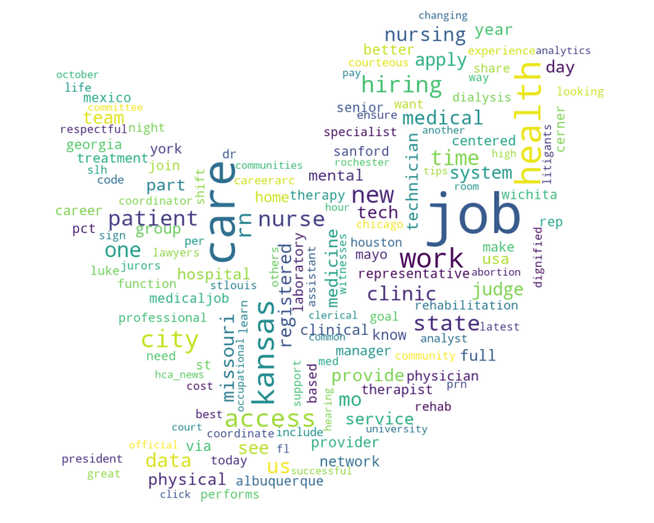

```python
show_words_cloud(techPositive.tokenText.str.cat(sep=' '), None, 150)
```

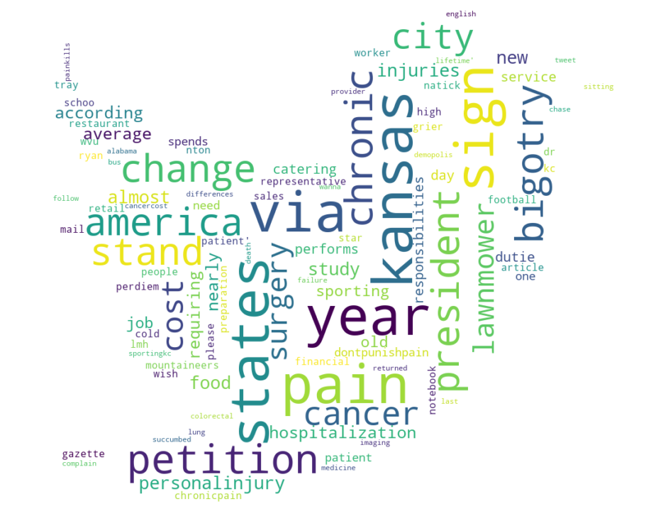

```python
show_words_cloud(techNegative.tokenText.str.cat(sep=' '), None, 100)
```

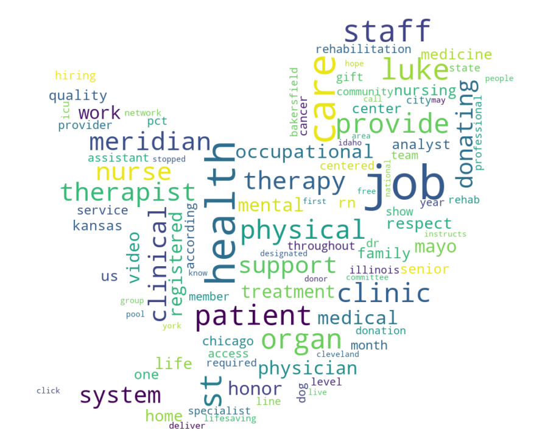

```python
show_words_cloud(wellBeingPositive.tokenText.str.cat(sep=' '), None, 100)
```

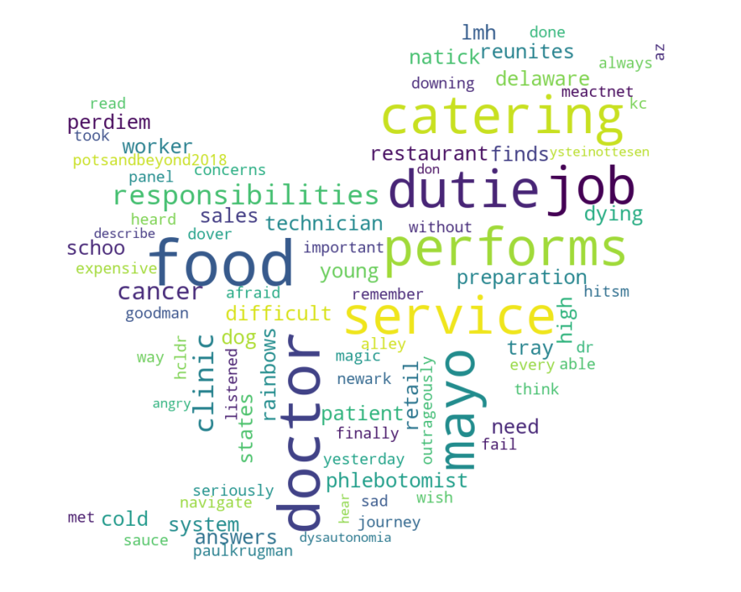

```python
show_words_cloud(wellBeingNegative.tokenText.str.cat(sep=' '), None, 100)
```

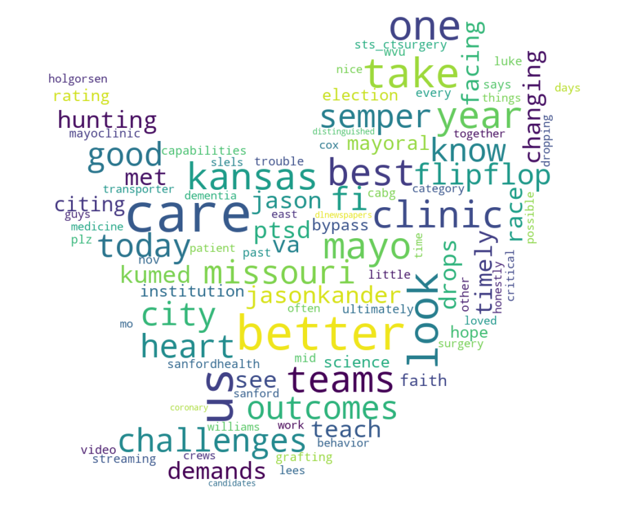

```python
show_words_cloud(areaImprovPositive.tokenText.str.cat(sep=' '), None, 100)
```

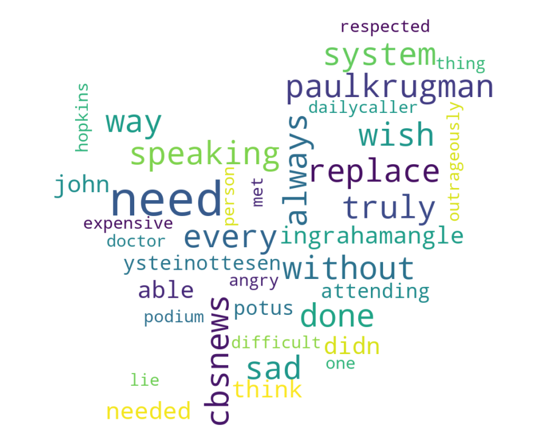

```python
show_words_cloud(areaImprovNegative.tokenText.str.cat(sep=' '), None, 100)
```